# Analisis Clustering Biji Gandum

Jacky Alinson

2026-06-06

# 1 Pendahuluan

Dataset **Seeds** merupakan kumpulan data morfometrik biji gandum yang berasal dari tiga varietas berbeda (*Kama*, *Rosa*, dan *Canadian*), masing-masing berjumlah 70 sampel sehingga total terdapat **210 observasi**. Setiap sampel memiliki 7 fitur geometris yang diukur menggunakan teknik sinar-X lunak beresolusi tinggi.

Tujuan analisis ini adalah **membandingkan dua algoritma clustering tanpa pengawasan (*unsupervised*)**, yaitu K-Means dan K-Medoids (PAM), dalam mengelompokkan biji gandum berdasarkan kemiripan fitur morfologisnya tanpa menggunakan label varietas sebagai panduan selama proses clustering.

# 2 Load Library & Data

## 2.1 Library yang Digunakan

```r
library(cluster)
library(factoextra)
library(ggplot2)
library(gridExtra)
library(clusterSim)
library(fpc)
library(mclust)
library(pheatmap)
library(tidyr)
```

## 2.2 Import Data

```r
seeds <- read.table(
  "C:/Users/jackyallea/Downloads/seeds/seeds_dataset.txt",
  header = FALSE,
  sep    = "",
  col.names = c(
    "area", "perimeter", "compactness",
    "kernel_length", "kernel_width",
    "asymmetry_coef", "groove_length",
    "variety"
  )
)

cat("Dimensi Data :", nrow(seeds), "x", ncol(seeds), "\n")
```

```
## Dimensi Data : 210 x 8
```

```r
cat("Missing Value:", sum(is.na(seeds)), "\n")
```

```
## Missing Value: 0
```

## 2.3 Eksplorasi Awal

```r
str(seeds)
```

```
## 'data.frame':    210 obs. of  8 variables:
##  $ area          : num  15.3 14.9 14.3 13.8 16.1 ...
##  $ perimeter     : num  14.8 14.6 14.1 13.9 15 ...
##  $ compactness   : num  0.871 0.881 0.905 0.895 0.903 ...
##  $ kernel_length : num  5.76 5.55 5.29 5.32 5.66 ...
##  $ kernel_width  : num  3.31 3.33 3.34 3.38 3.56 ...
##  $ asymmetry_coef: num  2.22 1.02 2.7 2.26 1.35 ...
##  $ groove_length : num  5.22 4.96 4.83 4.8 5.17 ...
##  $ variety       : int  1 1 1 1 1 1 1 1 1 1 ...
```

```r
summary(seeds)
```

```
##       area         perimeter      compactness     kernel_length
##  Min.   :10.59   Min.   :12.41   Min.   :0.8081   Min.   :4.899
##  1st Qu.:12.27   1st Qu.:13.45   1st Qu.:0.8569   1st Qu.:5.262
##  Median :14.36   Median :14.32   Median :0.8734   Median :5.524
##  Mean   :14.85   Mean   :14.56   Mean   :0.8710   Mean   :5.629
##  3rd Qu.:17.30   3rd Qu.:15.71   3rd Qu.:0.8878   3rd Qu.:5.980
##  Max.   :21.18   Max.   :17.25   Max.   :0.9183   Max.   :6.675
##   kernel_width   asymmetry_coef   groove_length      variety
##  Min.   :2.630   Min.   :0.7651   Min.   :4.519   Min.   :1
##  1st Qu.:2.944   1st Qu.:2.5615   1st Qu.:5.045   1st Qu.:1
##  Median :3.237   Median :3.5990   Median :5.223   Median :2
##  Mean   :3.259   Mean   :3.7002   Mean   :5.408   Mean   :2
##  3rd Qu.:3.562   3rd Qu.:4.7687   3rd Qu.:5.877   3rd Qu.:3
##  Max.   :4.033   Max.   :8.4560   Max.   :6.550   Max.   :3
```

```r
table(seeds$variety)
```

```
##
##  1  2  3
## 70 70 70
```

> **Catatan:** Dataset terdiri dari 210 baris dan 8 kolom. Tidak terdapat nilai hilang (*missing value*). Label varietas (`variety`) berdistribusi **seimbang** dengan masing-masing 70 sampel per kelas kondisi ideal untuk evaluasi clustering.

# 3 Preprocessing

Fitur ke-1 hingga ke-7 dipisahkan dari label, kemudian dilakukan **standardisasi (z-score scaling)** agar setiap fitur memiliki skala yang setara. Hal ini penting karena K-Means dan PAM menggunakan jarak Euclidean yang sensitif terhadap perbedaan satuan antar fitur.

```r
X        <- seeds[, 1:7]
X_scaled <- scale(X)
```

# 4 Eksplorasi Distribusi Fitur (Boxplot)

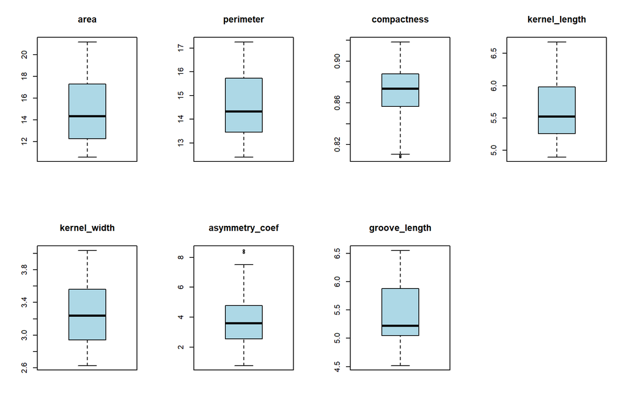

Gambar 1. Distribusi setiap fitur morfologis biji gandum sebelum scaling.

```r
par(mfrow = c(2, 4))
for (col in names(X)) {
  boxplot(X[[col]], main = col, col = "lightblue")
}
par(mfrow = c(1, 1))
```

**Interpretasi:** Sebagian besar fitur (area, perimeter, kernel_length, kernel_width, groove_length) memiliki distribusi yang relatif simetris tanpa pencilan ekstrem. Fitur `asymmetry_coef` menunjukkan distribusi yang lebih miring ke kanan (*right-skewed*) dengan beberapa pencilan di nilai tinggi, mengindikasikan variabilitas asimetri yang lebih besar antar biji. Fitur `compactness` memiliki rentang nilai sangat sempit (0.81–0.92), sehingga standardisasi menjadi penting untuk menghindari dominasi fitur berskala besar.

# 5 Penentuan Jumlah Cluster Optimal

## 5.1 Elbow Method (WSS)

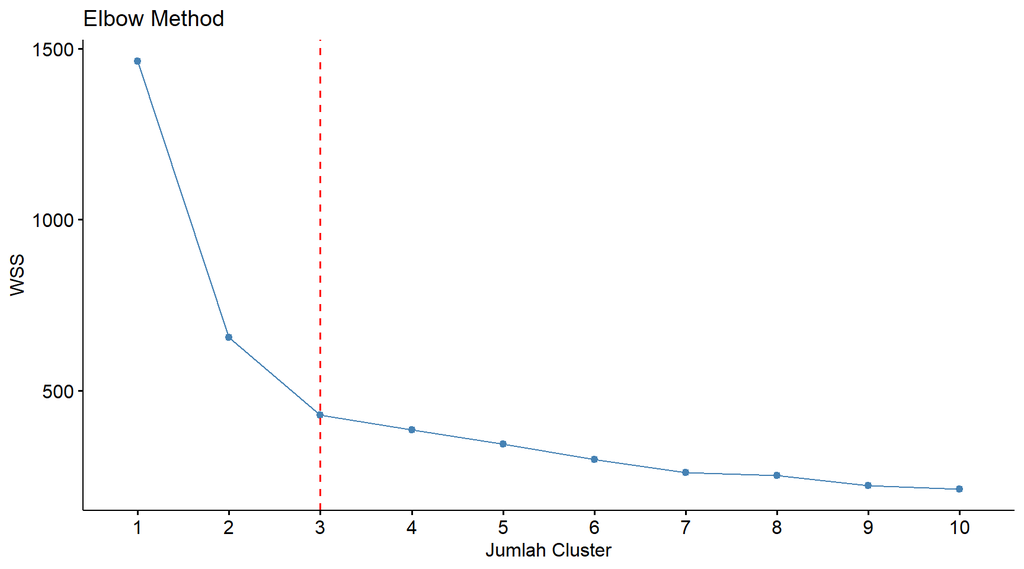

Gambar 2. Elbow Method — penurunan WSS terhadap jumlah cluster.

```r
set.seed(42)

fviz_nbclust(
  X_scaled, kmeans,
  method = "wss", k.max = 10
) +
  geom_vline(xintercept = 3, linetype = "dashed", color = "red") +
  labs(title = "Elbow Method", x = "Jumlah Cluster", y = "WSS")
```

**Interpretasi:** Grafik WSS (*Within-Cluster Sum of Squares*) menunjukkan penurunan tajam dari k=1 ke k=2, kemudian melambat secara signifikan mulai k=3. Titik “siku” (*elbow*) terbentuk jelas pada **k=3**, ditandai garis merah putus-putus. Penambahan cluster di atas k=3 tidak memberikan penurunan WSS yang berarti, sehingga k=3 dipilih sebagai jumlah cluster optimal berdasarkan metode ini.

## 5.2 Silhouette Method

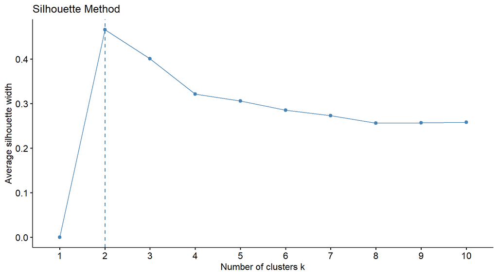

Gambar 3. Silhouette Method — rata-rata lebar silhouette per jumlah cluster.

```r
fviz_nbclust(
  X_scaled, kmeans,
  method = "silhouette", k.max = 10
) +
  labs(title = "Silhouette Method")
```

**Interpretasi:** Nilai rata-rata silhouette tertinggi diperoleh pada **k=2** (~0.46), lalu turun pada k=3 (~0.40). Meski secara matematis k=2 lebih optimal menurut metode silhouette, k=3 dipilih karena **sesuai dengan jumlah varietas yang diketahui** dari ground truth (3 kelas), serta didukung oleh hasil Elbow Method. Pada k=3, nilai silhouette masih tergolong cukup baik (~0.40), menandakan struktur cluster yang masih dapat diidentifikasi dengan baik.

> **Keputusan:** Jumlah cluster **K = 3** dipilih berdasarkan pertimbangan gabungan antara Elbow Method, Silhouette Method, dan pengetahuan domain (3 varietas gandum).

# 6 Proses Clustering

```r
km_result  <- kmeans(X_scaled, centers = 3, nstart = 25, iter.max = 100)
pam_result <- pam(X_scaled, k = 3)

cat("\nCLUSTER SIZE K-MEANS\n")
```

```
##
## CLUSTER SIZE K-MEANS
```

```r
print(km_result$size)
```

```
## [1] 67 71 72
```

```r
cat("\nCLUSTER SIZE PAM\n")
```

```
##
## CLUSTER SIZE PAM
```

```r
print(pam_result$clusinfo[, "size"])
```

```
## [1] 77 62 71
```

**Interpretasi:** K-Means menghasilkan cluster dengan ukuran yang relatif seimbang (67, 71, 72), sedangkan PAM menghasilkan distribusi yang sedikit lebih tidak merata (77, 62, 71). Cluster K-Means yang lebih proporsional konsisten dengan cara kerjanya yang mengoptimalkan pusat cluster secara iteratif, sementara PAM memilih medoid dari data aktual sehingga lebih dipengaruhi oleh kepadatan lokal data.

# 7 Visualisasi PCA: Ground Truth vs Hasil Clustering

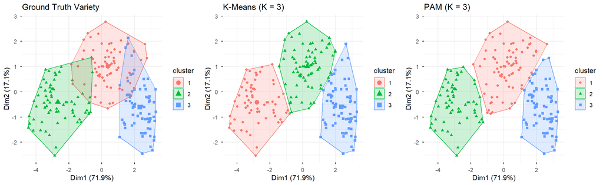

Gambar 4. Perbandingan visualisasi PCA: Ground Truth, K-Means, dan PAM.

```r
p0 <- fviz_cluster(
  list(data = X_scaled, cluster = seeds$variety),
  ellipse = TRUE, geom = "point",
  main = "Ground Truth Variety", ggtheme = theme_minimal()
)
p1 <- fviz_cluster(
  km_result, data = X_scaled,
  ellipse = TRUE, geom = "point",
  main = "K-Means (K = 3)", ggtheme = theme_minimal()
)
p2 <- fviz_cluster(
  pam_result, data = X_scaled,
  ellipse = TRUE, geom = "point",
  main = "PAM (K = 3)", ggtheme = theme_minimal()
)
grid.arrange(p0, p1, p2, ncol = 3)
```

**Interpretasi:** Dua komponen utama PCA mampu menjelaskan **89%** total variansi data (Dim1: 71.9%, Dim2: 17.1%). Pada plot *Ground Truth*, terlihat adanya tumpang tindih (*overlap*) antar varietas, terutama antara varietas 1 dan 2 yang menandakan tantangan inheren dalam separasi kelas pada data ini.

# 8 Uji Stabilitas Bootstrap K-Means

```r
set.seed(42)
boot_km <- clusterboot(
  X_scaled,
  B = 100, bootmethod = "boot",
  clustermethod = kmeansCBI,
  k = 3, seed = 42
)
```

[output not shown]

[output cut: 45 more lines]

[output not shown]

```r
cat("\nBOOTSTRAP STABILITY K-MEANS\n")
```

```
##
## BOOTSTRAP STABILITY K-MEANS
```

```r
print(round(boot_km$bootmean, 4))
```

```
## [1] 0.9562 0.8858 0.9177
```

**Interpretasi:** Uji stabilitas dengan 100 iterasi bootstrap menghasilkan nilai Jaccard rata-rata per cluster sebagai berikut:

| Cluster | Jaccard |
| --- | --- |
| 1 | 0.9562 |
| 2 | 0.8858 |
| 3 | 0.9177 |

Ketiga cluster memiliki nilai Jaccard **di atas 0.85**, yang merupakan ambang batas stabilitas tinggi. Ini berarti komposisi cluster K-Means **sangat konsisten** saat data di-resample, menunjukkan bahwa struktur cluster yang terbentuk bukan artefak dari inisialisasi acak, melainkan pola yang benar-benar ada di dalam data.

# 9 Evaluasi Metrik

```r
dmat <- dist(X_scaled)

sil_km  <- silhouette(km_result$cluster, dmat)
sil_pam <- silhouette(pam_result$clustering, dmat)

avg_sil_km  <- mean(sil_km[, 3])
avg_sil_pam <- mean(sil_pam[, 3])

db_km  <- index.DB(X_scaled, km_result$cluster)$DB
db_pam <- index.DB(X_scaled, pam_result$clustering)$DB

ch_km  <- calinhara(X_scaled, km_result$cluster)
ch_pam <- calinhara(X_scaled, pam_result$clustering)

ari_km  <- adjustedRandIndex(seeds$variety, km_result$cluster)
ari_pam <- adjustedRandIndex(seeds$variety, pam_result$clustering)
```

# 10 Tabel Perbandingan Metrik

```r
hasil <- data.frame(
  Metode = c("K-Means", "K-Medoids (PAM)"),
  Silhouette = round(c(avg_sil_km, avg_sil_pam), 4),
  Davies_Bouldin = round(c(db_km, db_pam), 4),
  Calinski_Harabasz = round(c(ch_km, ch_pam), 2),
  ARI = round(c(ari_km, ari_pam), 4),
  Jaccard_Bootstrap = c(round(mean(boot_km$bootmean), 4), NA)
)

knitr::kable(
  hasil,
  caption = "Tabel 1. Perbandingan metrik evaluasi K-Means dan PAM",
  align   = "lrrrrr"
)
```

Tabel 1. Perbandingan metrik evaluasi K-Means dan PAM

| Metode | Silhouette | Davies_Bouldin | Calinski_Harabasz | ARI | Jaccard_Bootstrap |
| --- | --- | --- | --- | --- | --- |
| K-Means | 0.4007 | 1.0047 | 249.78 | 0.7733 | 0.9199 |
| K-Medoids (PAM) | 0.3982 | 1.0115 | 247.33 | 0.7470 | NA |

**Interpretasi:**

| Metrik | K-Means | PAM | Lebih Baik | Keterangan |
| --- | --- | --- | --- | --- |
| Silhouette | **0.4007** | 0.3982 | K-Means | Kohesi & separasi cluster sedikit lebih baik |
| Davies-Bouldin | **1.0047** | 1.0115 | K-Means | Cluster lebih kompak dan terpisah |
| Calinski-Harabasz | **249.78** | 247.33 | K-Means | Rasio variansi antar/dalam cluster lebih tinggi |
| ARI | **0.7733** | 0.7470 | K-Means | Kesesuaian dengan label asli lebih tinggi |
| Jaccard Bootstrap | **0.9199** |  | K-Means | Cluster sangat stabil |

Secara keseluruhan, K-Means **unggul di semua metrik** meskipun selisihnya kecil. Nilai ARI K-Means sebesar 0.77 menunjukkan kesesuaian yang cukup tinggi dengan label varietas asli, mengindikasikan bahwa fitur morfologis biji gandum memang mengandung informasi diskriminatif antar varietas.

# 11 Silhouette Plot

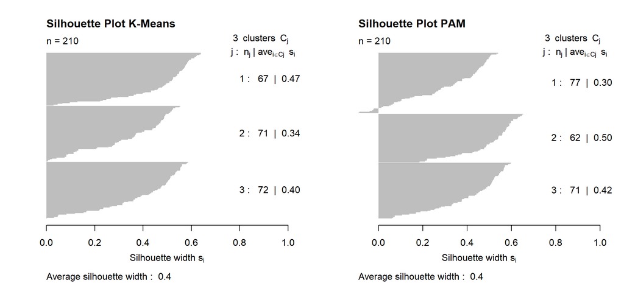

Gambar 5. Silhouette plot K-Means (kiri) dan PAM (kanan).

```r
par(mfrow = c(1, 2))
plot(sil_km,  main = "Silhouette Plot K-Means", border = NA)
plot(sil_pam, main = "Silhouette Plot PAM",     border = NA)
```

```r
par(mfrow = c(1, 1))
```

**Interpretasi:** Pada K-Means, silhouette per cluster adalah: C1=0.47, C2=0.34, C3=0.40. Cluster 1 memiliki separasi terbaik, sementara Cluster 2 adalah yang paling lemah, konsisten dengan zona overlap yang terlihat di plot PCA. Tidak ada nilai silhouette negatif yang berarti, sehingga tidak ada observasi yang secara tegas salah ditempatkan.

Pada PAM, distribusi nilai silhouette per cluster adalah: C1=0.30, C2=0.50, C3=0.42. Cluster 2 PAM justru memiliki nilai silhouette tertinggi, namun Cluster 1 paling lemah (0.30). Rata-rata keduanya setara (~0.40), namun K-Means menunjukkan distribusi yang lebih **merata antar cluster**.

# 12 Profil Cluster

```r
cluster_profile_km <- aggregate(X, by = list(Cluster = km_result$cluster), FUN = mean)
cat("\nPROFIL CLUSTER K-MEANS\n")
```

```
##
## PROFIL CLUSTER K-MEANS
```

```r
knitr::kable(cluster_profile_km, caption = "Tabel 2. Rata-rata fitur per cluster (K-Means)", digits = 3)
```

Tabel 2. Rata-rata fitur per cluster (K-Means)

| Cluster | area | perimeter | compactness | kernel_length | kernel_width | asymmetry_coef | groove_length |
| --- | --- | --- | --- | --- | --- | --- | --- |
| 1 | 18.495 | 16.203 | 0.884 | 6.176 | 3.698 | 3.632 | 6.042 |
| 2 | 14.438 | 14.338 | 0.882 | 5.515 | 3.259 | 2.707 | 5.121 |
| 3 | 11.857 | 13.248 | 0.848 | 5.232 | 2.850 | 4.742 | 5.102 |

```r
cluster_profile_pam <- aggregate(X, by = list(Cluster = pam_result$clustering), FUN = mean)
cat("\nPROFIL CLUSTER PAM\n")
```

```
##
## PROFIL CLUSTER PAM
```

```r
knitr::kable(cluster_profile_pam, caption = "Tabel 3. Rata-rata fitur per cluster (PAM)", digits = 3)
```

Tabel 3. Rata-rata fitur per cluster (PAM)

| Cluster | area | perimeter | compactness | kernel_length | kernel_width | asymmetry_coef | groove_length |
| --- | --- | --- | --- | --- | --- | --- | --- |
| 1 | 14.516 | 14.375 | 0.882 | 5.524 | 3.269 | 2.795 | 5.152 |
| 2 | 18.674 | 16.281 | 0.885 | 6.207 | 3.715 | 3.591 | 6.070 |
| 3 | 11.866 | 13.256 | 0.848 | 5.236 | 2.849 | 4.777 | 5.107 |

**Interpretasi (K-Means):**

| Cluster | Karakteristik Dominan | Identifikasi |
| --- | --- | --- |
| **C1** | Area (18.5), perimeter (16.2), groove_length (6.0) besar | Biji **besar** Varietas Rosa |
| **C2** | Nilai sedang di semua fitur | Biji **sedang** Varietas Kama |
| **C3** | Area kecil (11.9), asymmetry_coef tinggi (4.7) | Biji **kecil & asimetris** Varietas Canadian |

Profil PAM menghasilkan karakteristik yang sangat serupa, hanya berbeda pada penomoran cluster. Cluster berukuran besar, sedang, dan kecil dapat diidentifikasi dengan jelas dari kedua metode.

# 13 Heatmap Profil Cluster

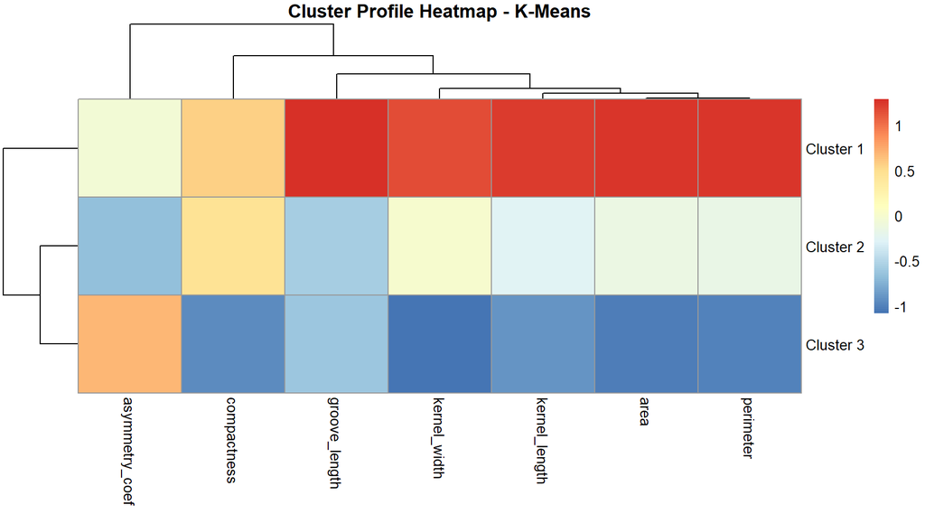

Gambar 6. Heatmap profil cluster K-Means (nilai terstandarisasi).

```r
profile_km_scaled <- aggregate(X_scaled, by = list(Cluster = km_result$cluster), FUN = mean)
rownames(profile_km_scaled) <- paste("Cluster", profile_km_scaled$Cluster)
profile_km_scaled <- profile_km_scaled[, -1]
pheatmap(profile_km_scaled, main = "Cluster Profile Heatmap - K-Means")
```

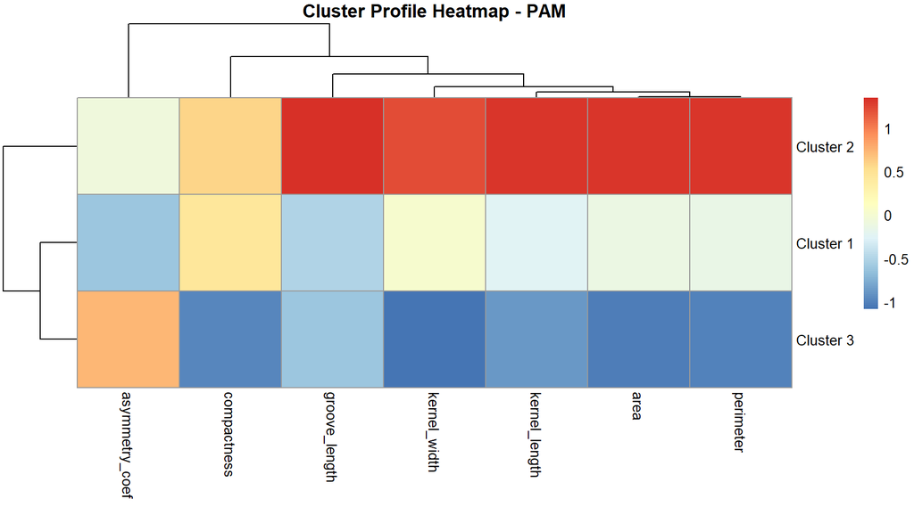

Gambar 7. Heatmap profil cluster PAM (nilai terstandarisasi).

```r
profile_pam_scaled <- aggregate(X_scaled, by = list(Cluster = pam_result$clustering), FUN = mean)
rownames(profile_pam_scaled) <- paste("Cluster", profile_pam_scaled$Cluster)
profile_pam_scaled <- profile_pam_scaled[, -1]
pheatmap(profile_pam_scaled, main = "Cluster Profile Heatmap - PAM")
```

# 14 Confusion Matrix

```r
cat("\nCONFUSION MATRIX K-MEANS\n")
```

```
##
## CONFUSION MATRIX K-MEANS
```

```r
cm_km <- table(Actual = seeds$variety, Cluster = km_result$cluster)
print(cm_km)
```

```
##       Cluster
## Actual  1  2  3
##      1  2 62  6
##      2 65  5  0
##      3  0  4 66
```

```r
cat("\nCONFUSION MATRIX PAM\n")
```

```
##
## CONFUSION MATRIX PAM
```

```r
cm_pam <- table(Actual = seeds$variety, Cluster = pam_result$clustering)
print(cm_pam)
```

```
##       Cluster
## Actual  1  2  3
##      1 64  1  5
##      2  9 61  0
##      3  4  0 66
```

**Interpretasi (K-Means):** Dari confusion matrix, dapat dihitung akurasi pengklasteran (setelah penyelarasan label):

- **Varietas 1 - Cluster 2**: 62 dari 70 benar (89%), 6 salah ke C3, 2 ke C1
- **Varietas 2 - Cluster 1**: 65 dari 70 benar (93%), 5 salah ke C2
- **Varietas 3 - Cluster 3**: 66 dari 70 benar (94%), 4 salah ke C2

**Interpretasi (PAM):** - **Varietas 1 - Cluster 1**: 64 dari 70 benar (91%) - **Varietas 2 - Cluster 2**: 61 dari 70 benar (87%) - **Varietas 3 - Cluster 3**: 66 dari 70 benar (94%)

PAM sedikit lebih lemah dalam memisahkan Varietas 2, namun lebih baik dalam memisahkan Varietas 1, dibanding K-Means.

# 15 Grafik Perbandingan Metrik

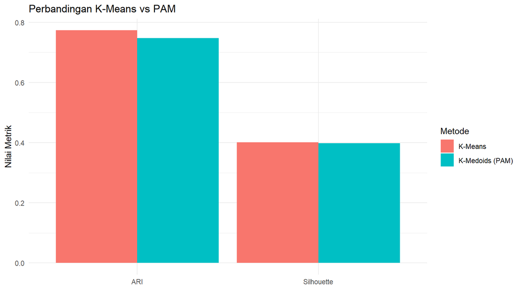

Gambar 8. Perbandingan nilai Silhouette dan ARI antara K-Means dan PAM.

```r
metric_plot <- hasil[, c("Metode", "Silhouette", "ARI")]
metric_plot <- pivot_longer(metric_plot, cols = c(Silhouette, ARI),
                            names_to = "Metric", values_to = "Value")

ggplot(metric_plot, aes(x = Metric, y = Value, fill = Metode)) +
  geom_col(position = "dodge") +
  labs(title = "Perbandingan K-Means vs PAM",
       x = NULL, y = "Nilai Metrik") +
  theme_minimal()
```

**Interpretasi:** Grafik batang memperjelas bahwa K-Means secara konsisten menghasilkan nilai yang lebih tinggi pada kedua metrik. Selisih ARI (~0.026) lebih besar secara relatif dibanding selisih Silhouette (~0.002), menunjukkan bahwa K-Means memiliki **kesesuaian lebih baik dengan label asli** bukan hanya struktur internal cluster yang lebih baik.

# 16 Kesimpulan

```r
best_sil <- ifelse(avg_sil_km > avg_sil_pam, "K-Means", "PAM")
best_db  <- ifelse(db_km < db_pam,           "K-Means", "PAM")
best_ch  <- ifelse(ch_km > ch_pam,           "K-Means", "PAM")
best_ari <- ifelse(ari_km > ari_pam,         "K-Means", "PAM")
votes    <- c(best_sil, best_db, best_ch, best_ari)
winner   <- names(sort(table(votes), decreasing = TRUE))[1]

cat("Silhouette        :", best_sil, "\n")
```

```
## Silhouette        : K-Means
```

```r
cat("Davies-Bouldin    :", best_db,  "\n")
```

```
## Davies-Bouldin    : K-Means
```

```r
cat("Calinski-Harabasz :", best_ch,  "\n")
```

```
## Calinski-Harabasz : K-Means
```

```r
cat("ARI               :", best_ari, "\n")
```

```
## ARI               : K-Means
```

```r
cat("\nMetode terbaik secara keseluruhan:", winner, "\n")
```

```
##
## Metode terbaik secara keseluruhan: K-Means
```